# 566_Final_Project

Matthew Stoebe

2024-10-05

# Introduction

The dataset analyzed in this report is webscraped rental data from Redfin, specifically for properties in Washington state. The data contians basic variables such as rent price, square footage, number of bedrooms, bathrooms, and property type, along with geographic information like latitude and longitude.

The primary motivation for this analysis is to explore rent patterns within Washington state to assist in making informed investment decisions regarding rental properties. By understanding the factors that influence rent prices, investors can better assess the market and make strategic choices in terms of property acquisition, pricing, and returns on investment.

# Rent Price Distribution

The following plots show the distribution of rental prices across all properties, with both the raw and log-transformed rent prices visualized to identify the range and concentration of rent values. We see that it is somewhat log normal, but we may not care about these high cost rentals in our analysis as we are focused on more standard investment strategies. As such, it is better for us to filter some of these out as outlines than to predict the log transformed values.

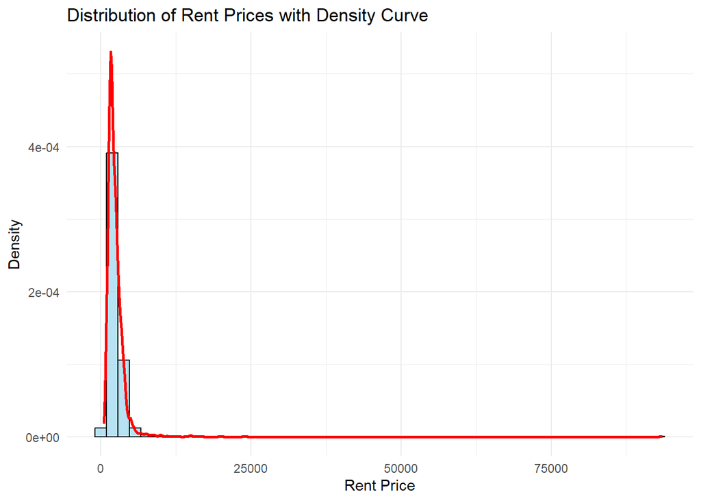

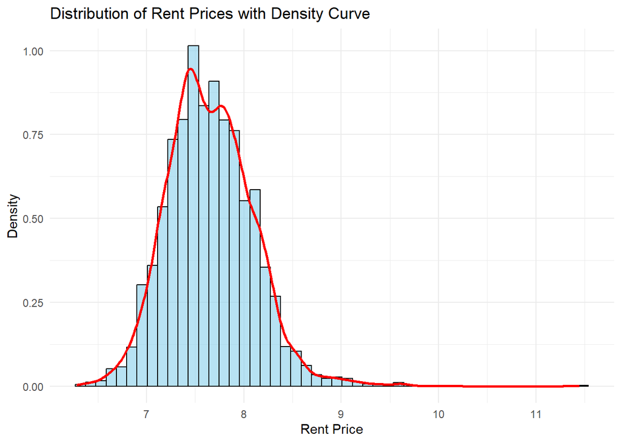

# Rent vs. Property Features

Next, we examine how rent prices vary based on property characteristics such as square footage, number of bedrooms, and bathrooms. The following scatter plots and regression lines show these relationships:

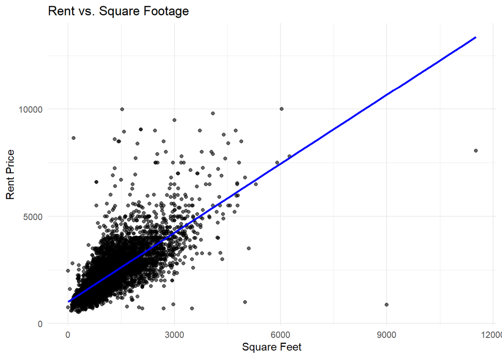

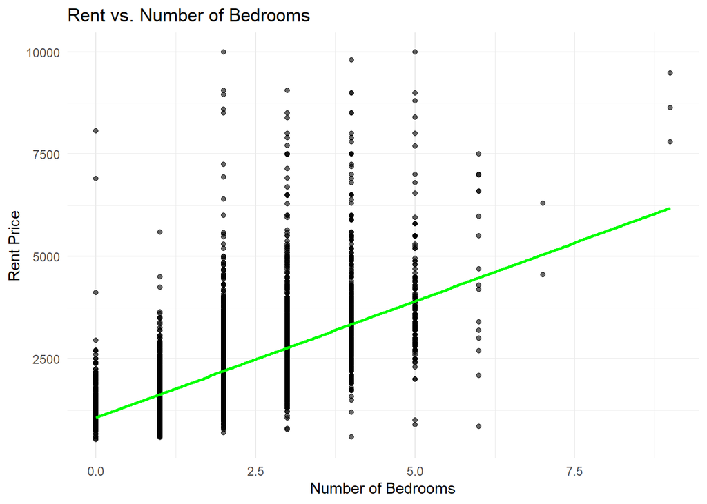

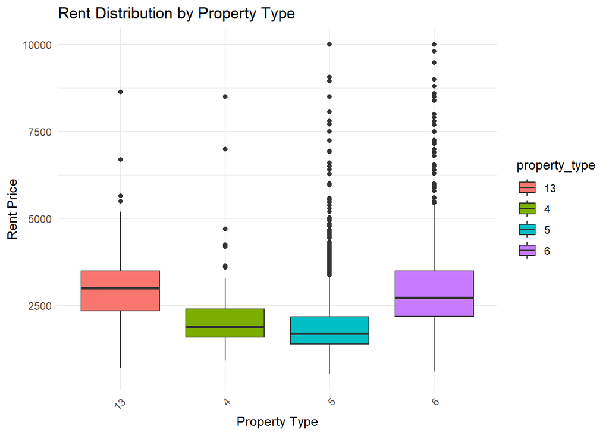

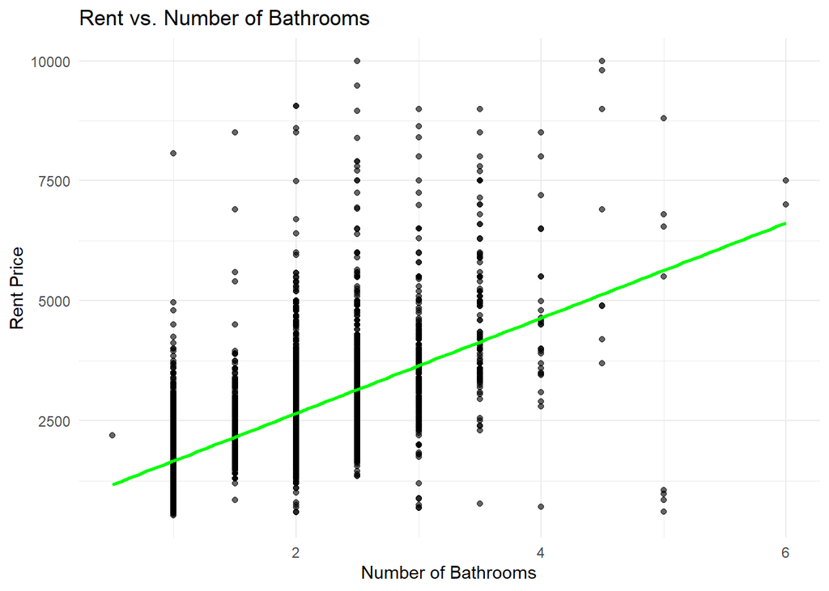

# Geographic Distribution of Rent Prices

Using a color gradient map, we visualize the spatial distribution of rent prices across Washington state. The color gradient represents the log-transformed rent prices, allowing us to observe regional variations in rental prices. This visual is not as efective since we are looking at individual rent values. It may be more valueable to look at clusters, or at avg rent by zip code to understand the spatial nature of rent prices

[interactive chart not shown]

# Pairs Plot, Feature Distribution and Multicolinearity Concerns

The following pair plot shows the pairwise relationships between key numeric features, including price, square footage, number of bedrooms, and bathrooms. WE also evaluate the risk of too much colinearity between features such as square feet and bedrooms

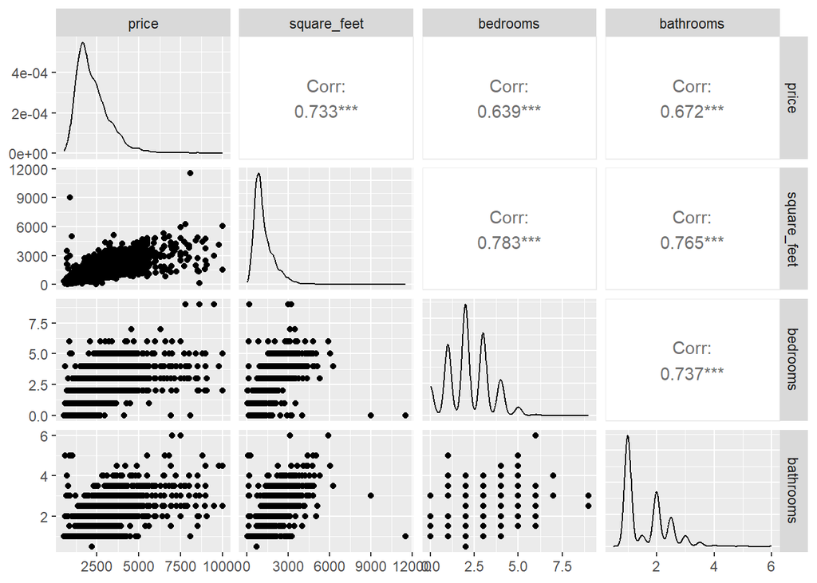

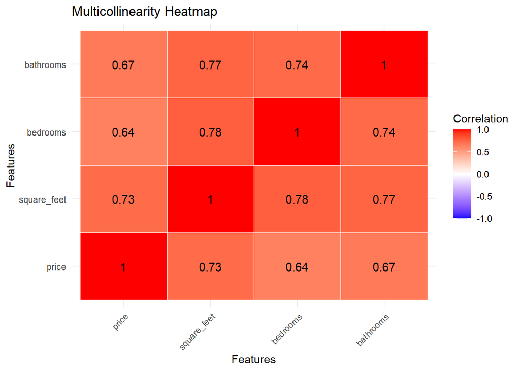

# Discussion

As suggested above, there are some concerns about the high correlation coefficients between each of these values. We do however have a lot of signal with rent, and may be able to effectively predict it, but most likely would need to look at other local features (like KNN) to get a good gauge of what standard rent prices are in the area or the county. This will help with prediction accuracy. Overall, I think that this is on the right track, but needs more feature engineering to make any real progress.